# Introduction to Python

This part of the course is focused on exploring what is python, installing required tools to run python apps, variables and building a simple Python app.

- What is Python?
- How to run Python Apps in Windows 10?
- Python Variables
- Writing a simple Python App

### What is Python?

Python is a general purpose, high level programming language. It does not require declarations of variabls, parameters, functions or methods in the source code. The python codes are short and flexible that enhances the readability of the python code.

- General purpose, high level programming language
- Python is object-oriented, dynamic and with strong typing, interpreted and interactive
- Python has clear and concise syntax which favors the readability of source code, and makes the language more productive
- Python is open source software (with license compatible with the General Public License (GPL)
- The language specification is maintained by the Python Software Foundation (PSF)

#### Python Users

- Google (Web Applications)
- Yahoo (Web Applications)
- Microsoft (IronPython: Python for. NET)
- Disney (3D animations)

#### Why Python?

> **It is easy to learn**
- Simple structure, clearly defined syntax & few keywords
- Portable, Scalable, Extendable & support for all major databases
- Availability of library:
  - Library : very portable and cross platform compatible
- Python supports interactive mode where lines of code are typed into a prompt (command line) shell similar to the operating system.

[figure not shown]

#### Python Environment

- Python is available for different platforms such as Linux, Mac OS or Windows
- Python may be already installed in your system, therefore you may check by typing “python” in a terminal window

#### Installing Python

- Python is available for variety of platforms
- Download the binary code or installation file for your platform & install Python https://www.python.org/downloads/

#### Installing Python in Windows 10

[video not shown]

### How to run your Python Apps?

- Using command-line interpreter
  - In Windows, by simply typing python at the command prompt
- Using the Python IDE (integrated development environment)
  - Anaconda Distribution – Open-Source https://www.anaconda.com/distribution/
  - PyCharm (Community – Open-Source https://www.jetbrains.com/pycharm/download/#section=windows
  - Mu https://codewith.mu/ Mu is a Python code editor for beginner programmers
  - Trinket https://trinket.io Trinket lets you run and write code in any browser, on any device. https://www.pythonanywhere.com/
  - Python Anywhere: a fully-fledged Python environment https://www.pythonanywhere.com/

### Writing your first Python Code – Interactive Mode

- Python Interactive Shell: The interactive mode is when you type commands into a tty (terminal typewriter).
- Start your command prompt or Powershell
- Type python and press enter in the command prompt
- print("hello world")

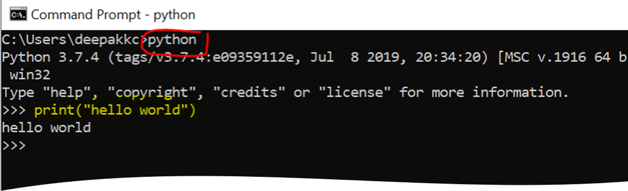

### Writing your first Python Code – Scripting Mode

- Use any text editor to write the python code and save it with an extension .py
- Go to command prompt and type python filename.py

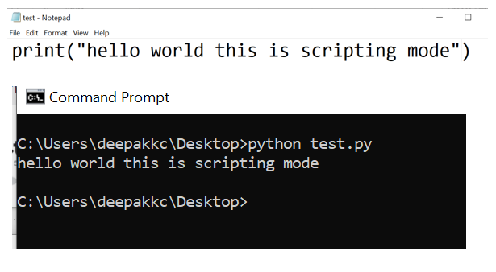

### Writing your first Python Code – Jypyter Notebook

- Run Anaconda Navigator
- Launch jupyter notebook, the jupyter dashboard opens in your browser >> Create a new notebook with python 3 >> type your code and click Run to run your code

[figure not shown]

### Identifiers in Python

- Identifiers are name used to identify a function, class, variable, module or an object
- Python identifier
  - Starts with a letter A – Z or an underscore ( _)
  - No punctuation characters such as @ $ are allowed in idetifiers
  - Case sensitive
  - Keywords cannot be used as identifiers

#### List of Keywords:

The keywords may change in different versions of Python.A new keyword might be added or deleted. To get the list of keywords, type the following commands:

```python
import keyword
print (keyword.kwlist)
```

[output not shown]

### Quotations in Python

- Both types of literals can be enclosed in matching single quotes (') or double quotes (").
- They can also be enclosed in matching groups of three single or double quotes (these are generally referred to as triple-quoted strings).
- The backslash () character is used to escape characters that otherwise have a special meaning, such as newline, backslash itself, or the quote character.

### Comments in Python

- A single line comment begins with the hash sign (#)
- All characters after # till the end of the line is a comment and the Python interpreter ignores them.
- Triple quotes (‘’’ or “””)can be used for multiple line comments

```python
# this is a single line comment
# another comment
# to writ multiple line comments, use triple quotes
'''
this is multiple line comment
here is one more line
'''
print("hello world")
```

### Multiple Line Statements

> To write multiple line statements, the line the line continuation character (\) is used.

```python
#Example of multiple line statements
# example 1
sum1=1 + 2 + 3 \
+ 4 + 5\
+ 6
print(sum1)
#exmaple 2
sum2=(1+2+3
      +4+5)
print(sum2)
#use semicolon to put mutliple line statements in a single line
a=1; b=5; c=6;
print(a+b+c)
```

### Writing a Simple Python App

```python
# Navigate to the folder where you want to create your first python app.
# Create a file and name it as test1.py
# type the following code
print "Hello world, we are learning python"

#To run the code in interactive mode, type python test1.py om ther terminal
# To run the code in jupyter notebook, Click Run on the top.
```

© Deepak KC - Last Updated on 9/9/2020